# Multi-Cluster Multi-Level Visualization with plot_mcml: A Complete Guide

### 11.3 Bootstrap stability per cluster

Bootstrap each cluster network independently to assess which transitions are stable:

```r
boot_macro <- Nestimate::bootstrap_network(grp$macro, iter = 500)
boot_dir   <- Nestimate::bootstrap_network(grp$Directive, iter = 500)
boot_eval  <- Nestimate::bootstrap_network(grp$Evaluative, iter = 500)
boot_meta  <- Nestimate::bootstrap_network(grp$Metacognitive, iter = 500)
```

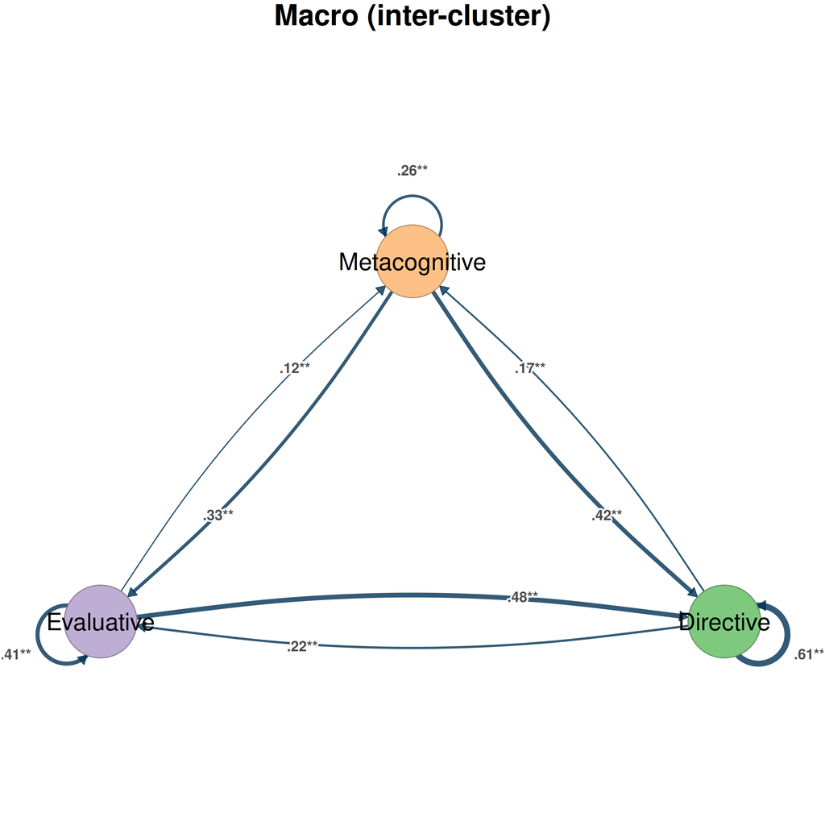

Figure 32: Bootstrap stability: macro network

```r
splot(boot_macro, title = "Macro (inter-cluster)")
```

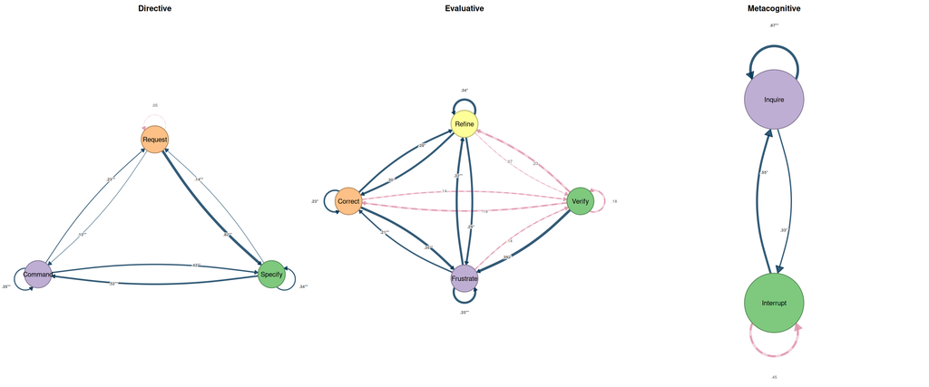

Figure 33: Bootstrap stability per cluster

```r
par(mfrow = c(1, 3))
splot(boot_dir, title = "Directive")
splot(boot_eval, title = "Evaluative")
splot(boot_meta, title = "Metacognitive")
```

### 11.4 Higher-order pathway analysis (HYPA)

Standard TNA models first-order transitions: which state follows the current state. But real behavioral sequences often have memory — the transition from state B depends not just on B but on the path that led to B. HYPA (Hypothesis testing for Path Anomalies) detects these higher-order dependencies by comparing observed pathway frequencies against a multi-hypergeometric null model (LaRock et al., 2020).

`build_hypa()` identifies pathways that are significantly over-represented (occurring more often than expected under the first-order model) or under-represented:

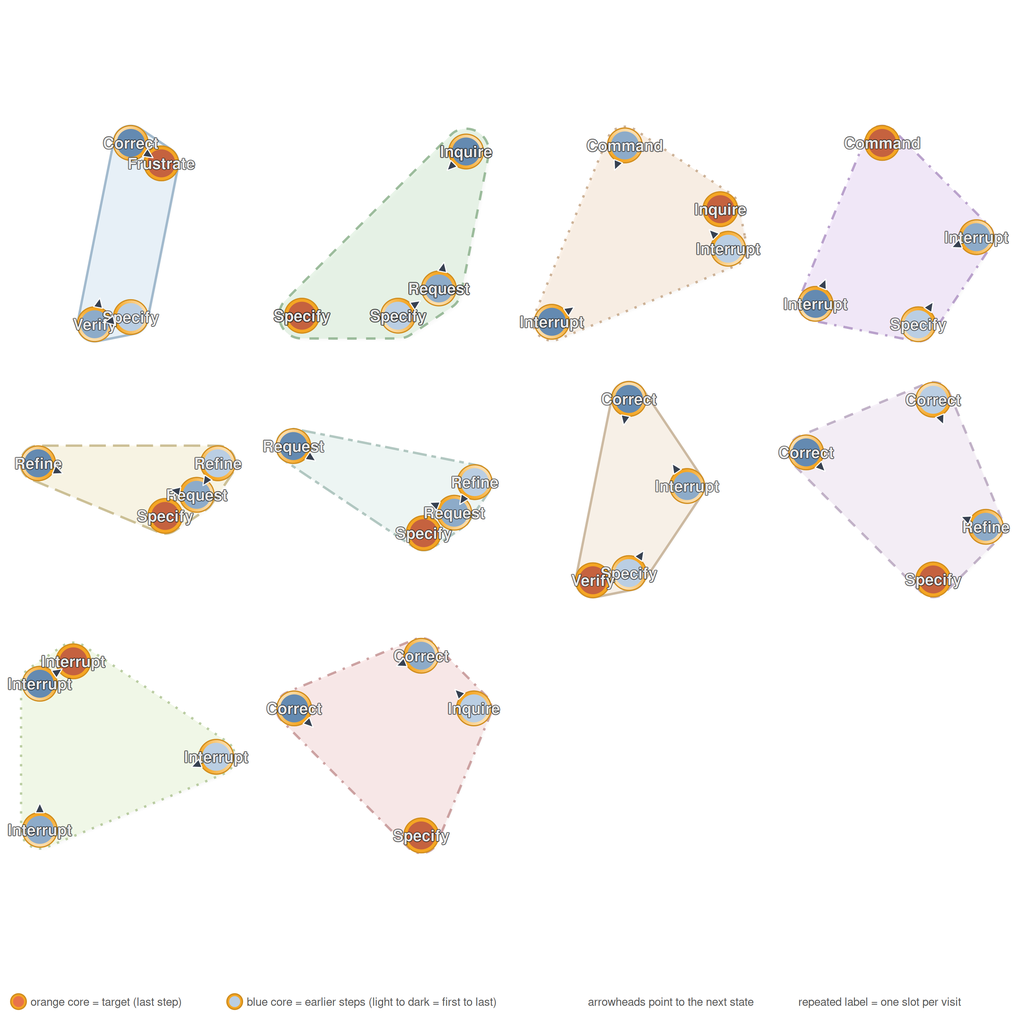

```r
hypa <- Nestimate::build_hypa(net, k = 3)

plot_simplicial(hypa, dismantled = TRUE)
```

### 11.5 Plotting individual clusters

Since each cluster is a `netobject`, all `splot()` styling works:

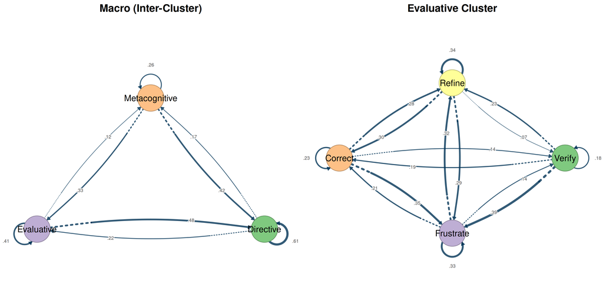

Figure 34: Left: macro-level inter-cluster network; Right: Evaluative cluster network

```r
par(mfrow = c(1, 2))

splot(grp$macro, title = "Macro (Inter-Cluster)")
splot(grp$Evaluative, title = "Evaluative Cluster")
```

## 12 Comparison: plot_mcml vs. plot_mtna vs. plot_mlna

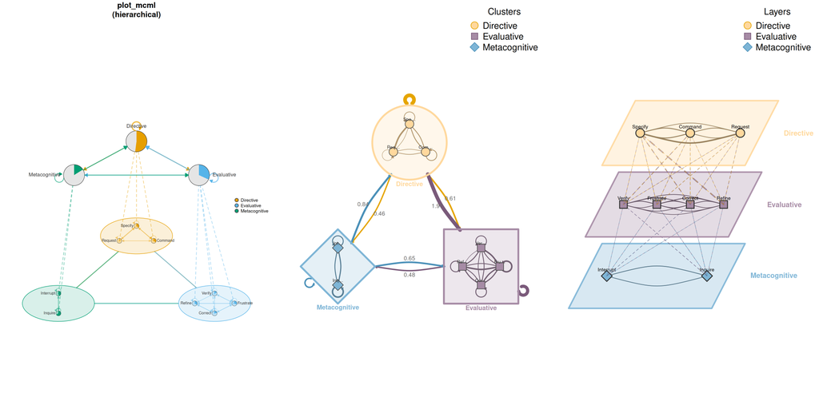

Figure 35: Three cluster visualization approaches side by side

```r
par(mfrow = c(1, 3), mar = c(1, 1, 2, 1))

plot_mcml(net, clusters, title = "plot_mcml\n(hierarchical)")
plot_mtna(net, clusters, show_labels = TRUE, label_abbrev = 4,
          title = "plot_mtna\n(flat clusters)")
plot_mlna(net, clusters, title = "plot_mlna\n(stacked layers)")
```

**`plot_mcml()`**: Two-layer hierarchical view. Bottom layer reveals individual dynamics; top layer shows macro structure. Best when you need both levels in a single figure.

**`plot_mtna()`**: Single flat layout with nodes inside cluster shapes. No vertical layering. Best for clean cluster maps.

**`plot_mlna()`**: Stacked layers in pseudo-3D. Each layer is an independent network level with inter-layer edges. Best for multilevel or multiplex data.

## 13 Parameter Quick Reference

| Category | Parameter | Default | Description |
| --- | --- | --- | --- |
| **Input** | `x` | — | Matrix, netobject, or mcml object |
|  | `cluster_list` | `NULL` | Named list of node vectors |
|  | `mode` | `"weights"` | `"weights"` or `"tna"` |
|  | `aggregation` | `"sum"` | `"sum"`, `"mean"`, `"max"` |
|  | `minimum` | `0` | Edge threshold |
| **Layout** | `spacing` | `3` | Cluster distance from center |
|  | `skew_angle` | `60` | Perspective tilt (0–90) |
|  | `shape_size` | `1.2` | Cluster shell radius |
|  | `top_layer_scale` | `c(0.8, 0.25)` | Macro oval `c(x, y)` |
|  | `inter_layer_gap` | `0.6` | Vertical gap multiplier |
|  | `node_radius_scale` | `0.55` | Node spread inside shell (0–1) |
| **Cluster nodes** | `node_size` | `1.8` | Node size |
|  | `node_shape` | `"circle"` | `"circle"`, `"square"`, `"diamond"`, `"triangle"` |
|  | `node_border_color` | `"gray30"` | Border color |
| **Macro nodes** | `summary_size` | `4` | Pie chart size |
|  | `cluster_shape` | `"circle"` | Macro node shape |
|  | `summary_pie` | `"inits"` | Pie meaning: `"inits"` or `"self"` |
|  | `summary_border_color` | `"gray20"` | Border color |
|  | `summary_border_width` | `2` | Border line width |
|  | `colors` | auto | Cluster colors |
| **Shells** | `shell_alpha` | `0.15` | Fill transparency |
|  | `shell_border_width` | `2` | Border width |
| **Cluster edges** | `edge_width_range` | `c(0.3, 1.3)` | Width range |
|  | `edge_alpha` | `0.35` | Transparency |
|  | `edge_labels` | `FALSE` | Show weight labels |
|  | `edge_label_size` | `0.5` | Label text size |
|  | `edge_label_color` | `"gray40"` | Label color |
|  | `edge_label_digits` | `2` | Decimal places |
| **Inter-cluster edges** | `between_edge_width_range` | `c(0.5, 2.0)` | Width range |
|  | `between_edge_alpha` | `0.6` | Transparency |
|  | `between_arrows` | `FALSE` | Arrowheads |
| **Macro edges** | `summary_edge_width_range` | `c(0.5, 2.0)` | Width range |
|  | `summary_edge_alpha` | `0.7` | Transparency |
|  | `summary_edge_labels` | `FALSE` | Show weight labels |
|  | `summary_edge_label_size` | `0.6` | Label text size |
|  | `summary_arrows` | `TRUE` | Arrowheads |
|  | `summary_arrow_size` | `0.10` | Arrowhead size |
| **Inter-layer** | `inter_layer_alpha` | `0.5` | Dashed line transparency |
| **Labels** | `show_labels` | `TRUE` | Show node labels |
|  | `label_size` | `0.6` | Node label text size |
|  | `label_color` | `"gray20"` | Node label color |
|  | `label_position` | `3` | 1=below, 2=left, 3=above, 4=right |
|  | `label_abbrev` | `NULL` | `NULL`, integer, or `"auto"` |
|  | `summary_labels` | `TRUE` | Show cluster labels |
|  | `summary_label_size` | `0.8` | Cluster label text size |
|  | `summary_label_color` | `"gray20"` | Cluster label color |
|  | `summary_label_position` | `3` | 1=below, 2=left, 3=above, 4=right |
| **Title/Legend** | `title` | `NULL` | Title text |
|  | `title_size` | `1.2` | Title text size |
|  | `subtitle` | `NULL` | Subtitle text |
|  | `subtitle_size` | `0.9` | Subtitle text size |
|  | `legend` | `TRUE` | Show legend |
|  | `legend_position` | `"right"` | `"right"`, `"left"`, `"top"`, `"bottom"` |
|  | `legend_size` | `0.7` | Legend text size |
|  | `legend_pt_size` | `1.2` | Legend symbol size |

## References

- LaRock, T., Scholtes, I., & Eliassi-Rad, T. (2020). HYPA: Efficient Detection of Path Anomalies in Time Series Data on Networks. In *Proceedings of the 2020 SIAM International Conference on Data Mining (SDM)* (pp. 460–468). SIAM.
- Saqr, M., López-Pernas, S., Törmänen, T., Kaliisa, R., Misiejuk, K., & Tikka, S. (2025). Transition Network Analysis: A Novel Framework for Modeling, Visualizing, and Identifying the Temporal Patterns of Learners and Learning Processes. In *Proceedings of the 15th International Learning Analytics and Knowledge Conference (LAK ’25)* (pp. 351–361). ACM. doi:10.1145/3706468.3706513
- Tikka, S., López-Pernas, S., & Saqr, M. (2025). tna: An R Package for Transition Network Analysis. *Applied Psychological Measurement*. doi:10.1177/01466216251348840